# Exploratory Data Analysis

Joe Kosteck, Ashley Klesmit, Dan Malee, Patrick McCullough

February 20, 2019

# Exploratory Data Analysis

This document serves to explore some attributes of interest in the data that we have collected thus far. Here, we will show the distribution of several attributes and their relationship to each other. The purpose of this exploration is for us to understand the main characteristics of the data, so that we have an intuitive sense of with what our group is working. We may also discover issues with the data, such as missingness or outliers that may have to be taken into consideration when conducting analysis.

There are two main data sources included in this analysis:

- Census Bureau<sup>1</sup>
  - Specifically, the 2013-2017 American Community Survey<sup>2</sup>
  - This data set contains over 25,000 attributes, including detailed population and housing data
  - Data is available at varying granularities, including county, city, census tract, and block group
- Zillow Research<sup>3</sup>
  - Contains detailed time series data for housing values and rental prices
  - Data available at varying granularities, although some data at smaller geography levels is missing for South Bend

### A Quick Note

While the vast majority of the code used to generate this analysis is excluded, below we have included our calls to the retrieve the Census Bureau. The main purpose this is included is for transparency. Additionally, if one examines the listing of the 25,000+ available variables from the census data, they will see it is broken into sections according to topic. Including the variable names as they are shown in the data will allow users to quickly search for similar variables if they are so inclined.

```r
rm(acs2017Variables)
censusVars <- c(
  `Total Population` = "B01003_001",
  `Total Housing Units` = "B25001_001",
  `Total Occupied Housing Units` = "B25002_002",
  `Total Vacant Housing Units` = "B25002_003",
  `Total Owner-Occupied Units` = "B25003_002",
  `Total Renter-Occupied Units` = "B25003_003",
  `Total For-Rent Units` = "B25004_002",
  `Total Rented Non-Occ Units` = "B25004_003",
  `Total For-Sale Units` = "B25004_004",
  `Total Sold Non-Occ Units` = "B25004_005",
  `Med Rent/Income%` = "B25071_001",
  `25% Owner Occ Housing Val` = "B25076_001",
  `50% Owner Occ Housing Val` = "B25077_001",
  `75% Owner Occ Housing Val` = "B25078_001",
  `Med Owner Costs-Mortgage` = "B25088_002",
  `Med Owner Costs-No Mortgage` = "B25088_003",
  `Med Costs/Income%-Mortgage` = "B25092_002",
  `Med Costs/Income%-No Mortgage` = "B25092_003",
  `Med Monthly Housing Costs` = "B25105_001",
  `Med Family Income` = "B19113_001",
  `Med Rent-No Bedrooms` = "B25031_002",
  `Med Rent-1 Bedroom` = "B25031_003",
  `Med Rent-2 Bedrooms` = "B25031_004",
  `Med Rent-3 Bedrooms` = "B25031_005",
  `Med Rent-4 Bedrooms` = "B25031_006",
  `Med Rent-5+ Bedrooms` = "B25031_007",
  `Med Rent` = "B25064_001"
)

stJoesTract <- get_acs(
  geography = "tract",
  variables = censusVars,
  state = "IN",
  county = "St. Joseph County",
  output = "wide",
  geometry = TRUE
)


stJoesBlockGroup <- get_acs(
  geography = "block group",
  variables = censusVars,
  state = "IN",
  county = "St. Joseph County",
  output = "wide",
  geometry = TRUE
)

stJoesTract <- sf::st_transform(stJoesTract, 4326)
stJoesBlockGroup <- sf::st_transform(stJoesBlockGroup, 4326)
```

## Boundaries

As stated above, both the Census Bureau and Zillow data is available at different geography sizes. Below, the boundaries for these different geometries is shown. When clicked, the name of that geometric area will appear.

[interactive chart not shown]

## Census Data

This exploratory analysis will focus on the census tract data, as the block group data can be overwhelming to visualize.

There are 75 distinct census tracts. Below is the quantile distribution of each attribute in the census tract data.

```
##  Total Population Total Housing Units Total Occupied Housing Units
##  Min.   : 683     Min.   : 424        Min.   : 284.0
##  1st Qu.:2140     1st Qu.: 912        1st Qu.: 775.5
##  Median :3086     Median :1379        Median :1198.0
##  Mean   :3582     Mean   :1548        Mean   :1342.6
##  3rd Qu.:4546     3rd Qu.:1830        3rd Qu.:1710.0
##  Max.   :8543     Max.   :4550        Max.   :3807.0
##
##  Total Vacant Housing Units Total Owner-Occupied Units
##  Min.   :  1.0              Min.   :  88.0
##  1st Qu.: 94.5              1st Qu.: 451.5
##  Median :171.0              Median : 686.0
##  Mean   :205.1              Mean   : 911.5
##  3rd Qu.:272.0              3rd Qu.:1321.5
##  Max.   :766.0              Max.   :2930.0
##
##  Total Renter-Occupied Units Total For-Rent Units
##  Min.   :  14.0              Min.   :  0.00
##  1st Qu.: 181.5              1st Qu.:  8.50
##  Median : 339.0              Median : 28.00
##  Mean   : 431.1              Mean   : 65.43
##  3rd Qu.: 557.0              3rd Qu.: 63.00
##  Max.   :2051.0              Max.   :708.00
##
##  Total Rented Non-Occ Units Total For-Sale Units Total Sold Non-Occ Units
##  Min.   :  0.00             Min.   :  0.00       Min.   :  0.00
##  1st Qu.:  0.00             1st Qu.:  0.00       1st Qu.:  0.00
##  Median :  0.00             Median :  0.00       Median :  0.00
##  Mean   : 16.36             Mean   : 16.08       Mean   : 12.89
##  3rd Qu.: 18.50             3rd Qu.: 21.00       3rd Qu.: 17.50
##  Max.   :236.00             Max.   :162.00       Max.   :100.00
##
##  Med Rent/Income% 25% Owner Occ Housing Val 50% Owner Occ Housing Val
##  Min.   :12.90    Min.   : 21700            Min.   : 28700
##  1st Qu.:23.62    1st Qu.: 45100            1st Qu.: 67350
##  Median :28.05    Median : 70650            Median : 99100
##  Mean   :29.07    Mean   : 77612            Mean   :107199
##  3rd Qu.:33.30    3rd Qu.:104325            3rd Qu.:144400
##  Max.   :50.00    Max.   :185000            Max.   :262600
##  NA's   :1        NA's   :1
```

[output cut: 33 more lines]

```
##  Min.   : 528.0      Min.   : 528.0      Min.   : NA
##  1st Qu.: 795.2      1st Qu.: 859.0      1st Qu.: NA
##  Median : 886.0      Median : 917.0      Median : NA
##  Mean   : 908.3      Mean   : 962.8      Mean   :NaN
##  3rd Qu.: 994.8      3rd Qu.: 957.0      3rd Qu.: NA
##  Max.   :1455.0      Max.   :2429.0      Max.   : NA
##  NA's   :11          NA's   :58          NA's   :75
##     Med Rent
##  Min.   : 266.0
##  1st Qu.: 676.0
##  Median : 757.0
##  Mean   : 805.2
##  3rd Qu.: 852.0
##  Max.   :1865.0
##  NA's   :2
```

Next, several of the attributes are visualized geographically. The checkboxes can be used toggle which attribute the viewer would like to explore. Additionally, when a boundary is clicked, the values for that area will be displayed.

[interactive chart not shown]

Below, we can see the relationship between the median rent price and median home value. Each dot is colored by the population in that area.

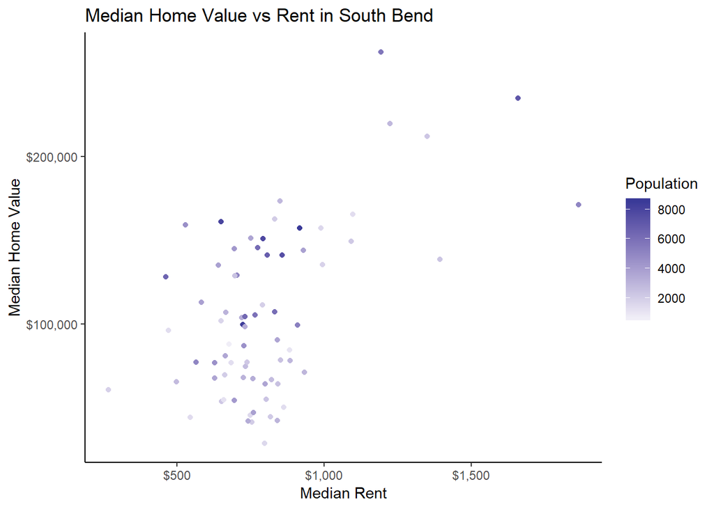

Next, we can see boxplots with the monthly home ownership costs for owners with and without a mortgage. Selected monthly owner costs are calculated from the sum of payment for mortgages, real estate taxes, various insurances, utilities, fuels, mobile home costs, and condominium fees.

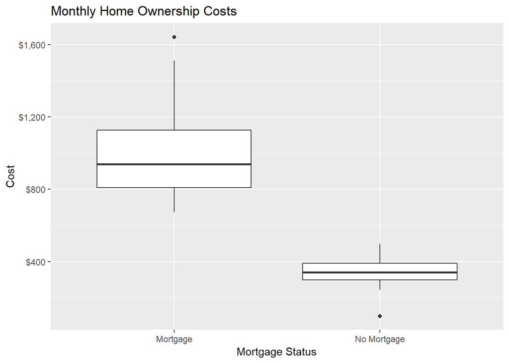

Lastly, we can see boxplots of rental costs versus the number of bedrooms.

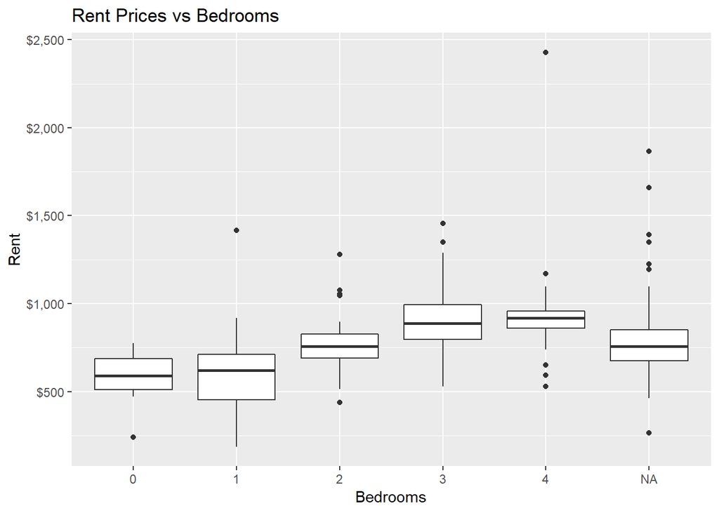

## Zillow Time Series Data

Next, we’ll look at time series data from Zillow.

The first plot shows how rent prices have changed over time in each of the South Bend neighborhoods that Zillow recognizes. This plot, however, is quite busy.

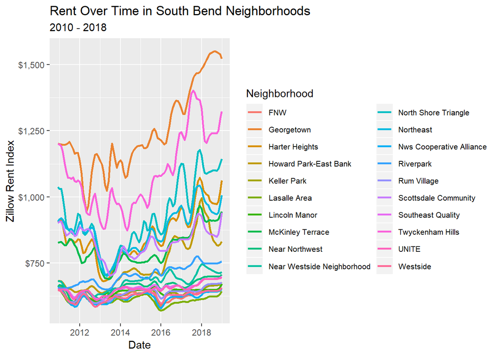

This plot displays similar information in a more aesthetically pleasing manner. Each dot represents a data point in the time series. The relative width of a given line shows how much that neighborhood’s rent has changed since 2010.

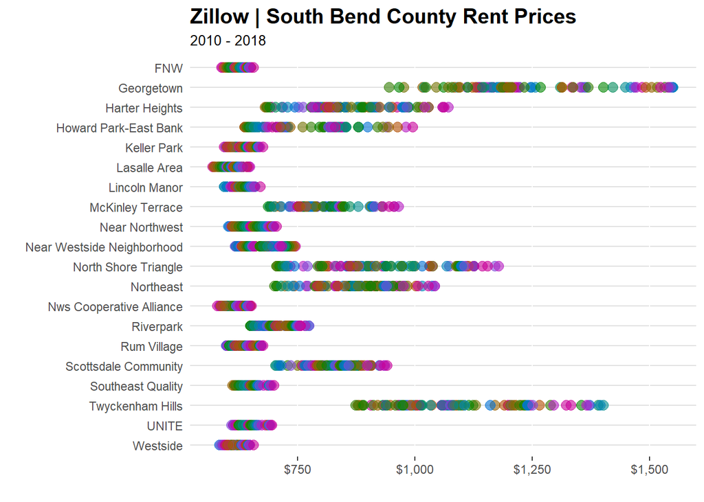

The next plot shows how home prices for select neighborhoods have changed over time. Unfortunately, there is a gap Zillow’s data here. Zillow did not have any other neighborhoods’ data available in this set.

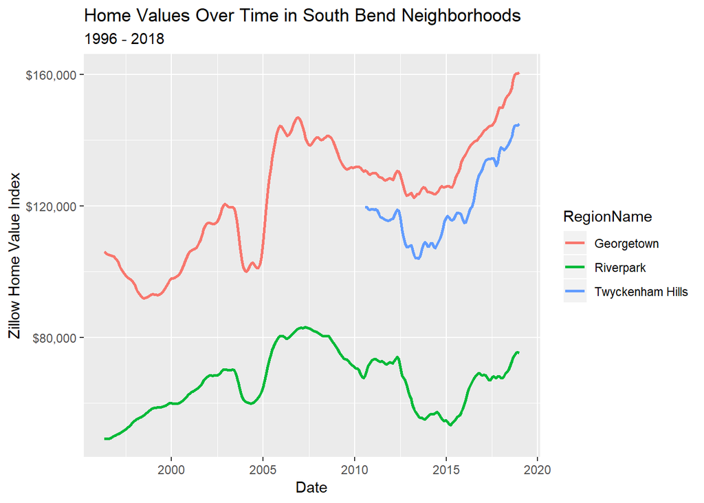

[figure not shown]

Lastly, Zillow breaking city-level housing data into three distinct tiers: bottom, middle, and top. The top and middle tier data sets do not contain information about South Bend and limited data about other cities in the region. Thus, this comparison will be done with the “bottom tier” time series. It is unclear how Zillow separates these cities in tiers or even what the meaning behind each tier could be.

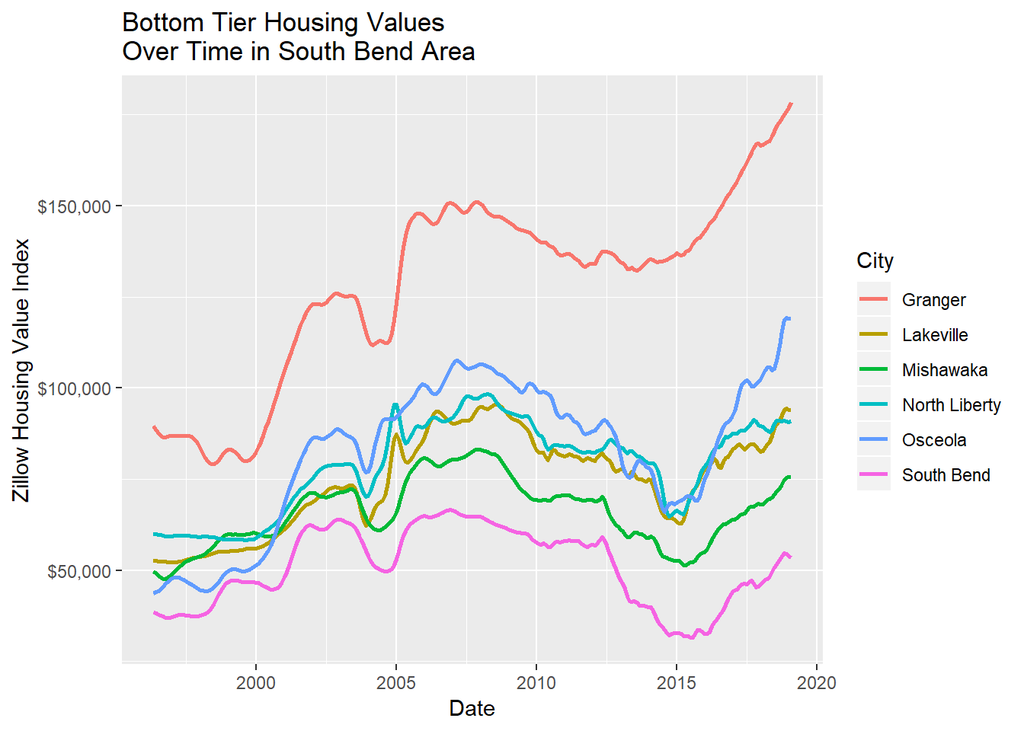

## Other Data Sources

Other data sources that we are looking to explore:

- National Historical GIS<sup>4</sup> - an organization that creates time series from census data
- St. Joseph County Assessor Property Sales<sup>5</sup> - public records of properties sold in the county

### Reference Links

1. https://www.census.gov/
2. https://www.census.gov/programs-surveys/acs/news/data-releases.html?#
3. https://www.zillow.com/research/data/
4. https://www.nhgis.org/
5. http://in-stjoseph-assessor.governmax.com/propertymax/agency/in-stjoseph-assessor/in-stjoseph_homepage.asp?sid=AEDF4B31EBD341F9B1E982AB51B0A7B5